# NeRV and JSE

January 7, 2018

Up: [Documentation Home](https://jlmelville.github.io/smallvis/).

[NeRV](http://www.jmlr.org/papers/v11/venna10a.html) and [JSE](https://dx.doi.org/10.1016/j.neucom.2012.12.036) are methods to related to SNE that both use a weighted sum of two different Kullback-Leibler divergences.

NeRV is the simplest, with the cost function being:

$$C_{NeRV} = \lambda D_{KL}(P||Q) + \left(1 - \lambda \right) D_{KL}(Q||P) = \\
\lambda \sum_{ij} p_{ij} \log \left( \frac{p_{ij}}{q_{ij}} \right)
+
\left(1 - \lambda \right) \sum_{ij} q_{ij} \log \left( \frac{q_{ij}}{p_{ij}} \right)$$

The JSE cost function is related to the Jensen-Shannon divergence:

$$C_{JSE} = D_{JS}(P||Q) = \frac{1}{1 - \kappa}D_{KL}(P||Z) + \frac{1}{\kappa} D_{KL}(Q||Z)$$

where $Z$ is a mixture of $P$ and $Q$:
$$Z = \kappa P + \left(1- \kappa \right)Q$$

Both methods use the same normalization and output kernel as ASNE, and by setting the weighting parameter in the cost function appropriately, ASNE results can be generated. For NeRV this means setting $\lambda = 1$ and for JSE, it’s when $\kappa = 0$. This does unfortunately mean you have to remember that the two Greek symbols, while doing basically the same job in NeRV and JSE, have the opposite effect on each other when changing the weighting parameter from 0 to 1 in the cost functions.

The NeRV paper presents an information retrieval interpretation of the cost function, where $\lambda$ controls the relative weight of false positive to false negative penalization. This makes sense when you consider that the normal Kullback-Leibler divergence penalizes small output probabilities that have large input probabilities, i.e. pairs of points that should have close distances but are too far apart. These can be considered false negatives in the information retrieval interpretation. Conversely, large output probabilities with small input probabilities suffer a much smaller penalty. This corresponds to points that ought to be placed far away but end up close together. These are false positives. So the standard KL divergence used in SNE can be considered to do its best to preserve local neighborhoods, at the cost of allowing points that aren’t neighbors to end up close together. By using a KL divergence where the role of $P$ and $Q$ is reversed, we get a cost function that places a larger importance on penalizing false positives, i.e. a layout where neighborhoods aren’t fully reproduced, but if two points *are* close together, we can be reasonably confident they really should be.

By blending the two divergences, we may get a cost function that can balance these opposing forces, and provide an extra “push” to some points that could work equivalently to replacing the Gaussian output kernel in ASNE and SSNE with the t-distributed kernel in t-SNE.

## Gradients

The JSE and NeRV gradients can be written as:

$$\frac{\partial C}{\partial \mathbf{y_i}} =
2 \sum_{j} \left(
k_{ij}
+
k_{ji}
\right)
\left(\mathbf{y_i} - \mathbf{y_j}\right)$$

where $\mathbf{y_i}$ is the output coordinate of point $i$, and $k_{ij}$ is the force constant between points $i$ and $j$, with different methods producing different force constants. Because of the point-wise nature of the normalization used in both methods, the force constant matrix $K$ is not symmetric, so $k_{ij} \neq k_{ji}$.

For NeRV, the force constant is:

$$k_{ij} =
\lambda
\left(
{p_{ij}} - {q_{ij}}
\right)
+
\left(1 - \lambda\right) q_{ij}
\left[
\log
\left( \frac{p_{ij}}{q_{ij}} \right)
+
D_{KL}(Q||P)
\right]$$

where $D_{KL}(Q||P)$ is the “reverse” Kullback-Leibler divergence.

For JSE, the force constant is:

$$k_{ij} =
\frac{q_{ij}}{\kappa}
\left[
\log
\left( \frac{z_{ij}}{q_{ij}} \right)
+
D_{KL}(Q||Z)
\right]$$

## Datasets

See the [Datasets](https://jlmelville.github.io/smallvis/datasets.html) page.

## Evaluation

Apart from visualizing the results, the mean neighbor preservation of the 40 closest neighbors is used to provide a rough quantification of the quality of the result, labelled as `mnp@40` in the plots.

## Settings

Example commands for using NeRV and JSE are given below for the `iris` dataset.

```
# default NeRV lambda = 0.9
iris_nerv <- smallvis(iris, scale = FALSE, perplexity = 40, Y_init = "spca", method = "nerv", ret_extra = c("dx", "dy"), eta = 0.1, max_iter = 2000, tol = 1e-8)

# non-default NeRV lambda = 0.1
iris_nerv0_1 <- smallvis(iris, scale = FALSE, perplexity = 40, Y_init = "spca", method = list("nerv", lambda = 0.1),
ret_extra = c("dx", "dy"), eta = 0.1, max_iter = 2000, tol = 1e-8)

# default JSE kappa = 0.5
iris_jse <- smallvis(iris, scale = FALSE, perplexity = 40, Y_init = "spca", method = "jse", ret_extra = c("dx", "dy"), eta = 0.1, max_iter = 2000, epoch = 100, final_momentum = 0.25, tol = 1e-8)
```

The default `lambda` is based on some applications of NeRV by [Yang, Peltonen and Kaski](http://proceedings.mlr.press/v38/yang15a.html). JSE’s default `kappa` was set to 0.5 in accord with the settings used for JSE in the [multiscale JSE paper](https://dx.doi.org/10.1016/j.neucom.2014.12.095).

On the `fashion6k` dataset, JSE with `kappa = 0.9` optimizes stably and seems to be converging before suddenly blowing up. The onset of this seems to be a single point being moved a large distance. It appears to be related to the `final_momentum` parameter, rather than minimum step size (controlled by `min_gain`).

Apart from this slight wrinkle, the DBD method does seem to do an ok job at optimizing. Futher improvements to the final error can be realized by starting a new optimization with the final DBD coordinates using L-BFGS, but there’s no large change to the output coordinates.

An example of this two-stage optimization (along with specifying a non-default value of `kappa`) is given by:

```
fashion_jse0_9_short <- smallvis(fashion6k, scale = FALSE, perplexity = 40, Y_init = "spca", method = list("jse", kappa = 0.9), ret_extra = c("dx", "dy"), eta = 0.1, max_iter = 500, tol = 1e-8, final_momentum = 0.25)

fashion_jse0_9_shortl <- smallvis(fashion6k, scale = FALSE, perplexity = 40, Y_init = fashion_jse0_9_short$Y, method = list("jse", kappa = 0.9), ret_extra = c("dx", "dy"), max_iter = 500, tol = 1e-8, epoch = 10, opt = list("l-bfgs", max_fg = 500))
```

## Results: NeRV

Results are show in the order where the top left image is the setting closest to the pure “reverse” KL divergence and the bottom right image is the ASNE result, which represents the pure “forward” KL divergence. Going from left to right and then top to bottom, more of the forward KL divergence is added to the cost function, which is indicated by the value of `lambda` increasing.

### iris

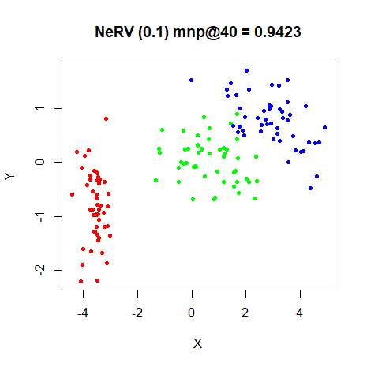

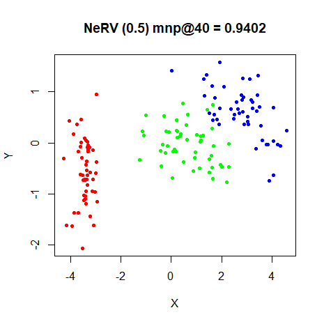

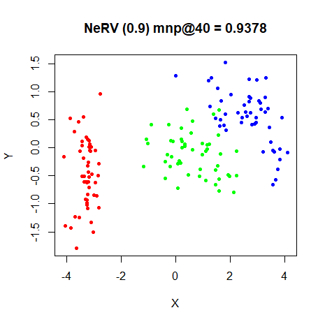

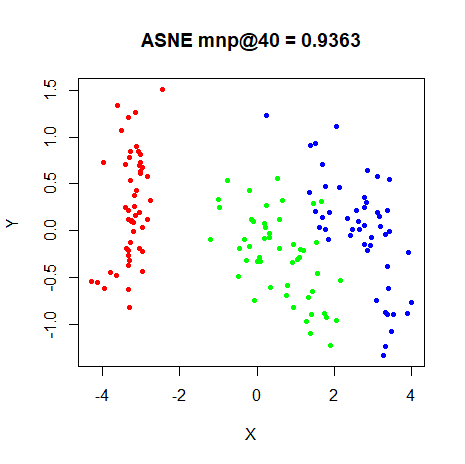

### s1k

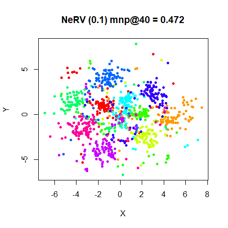

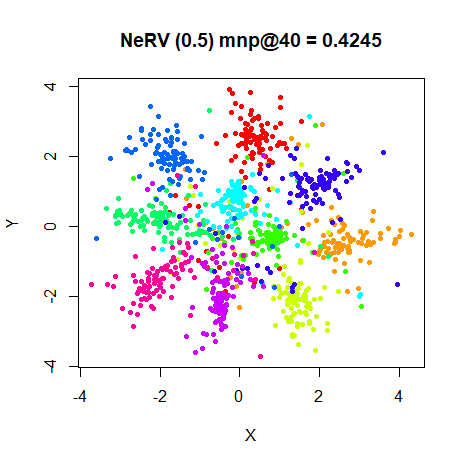

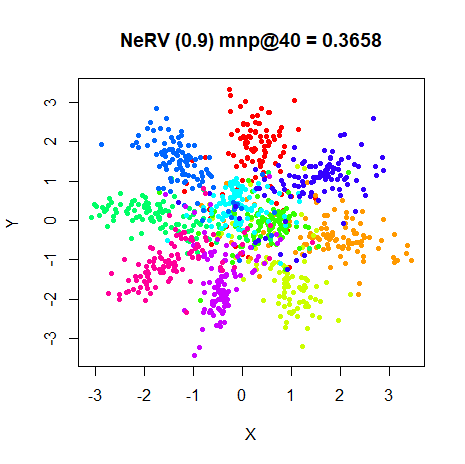

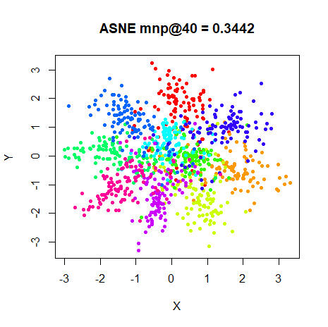

### oli

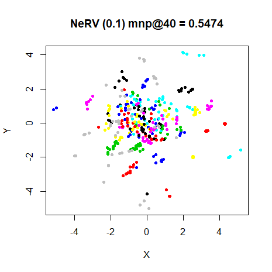

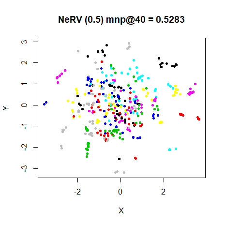

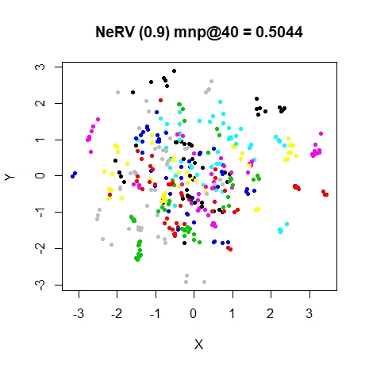

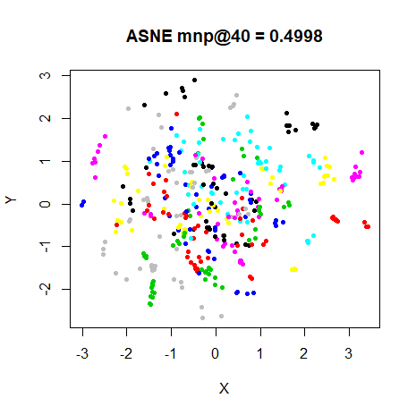

### frey

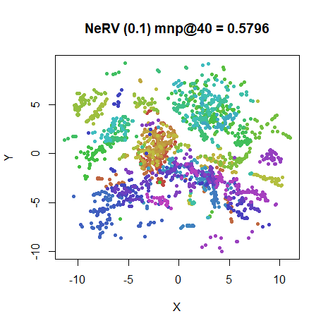

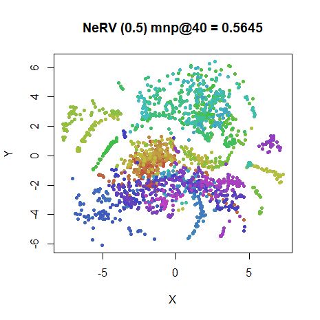

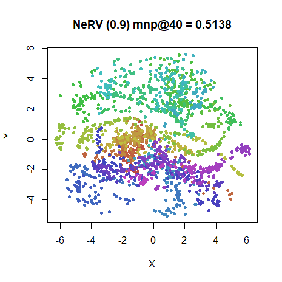

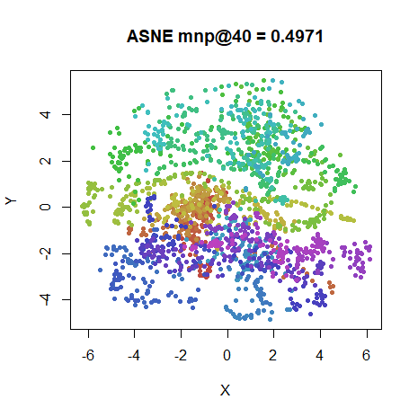

### coil20

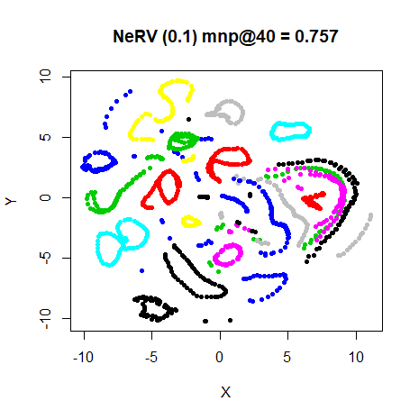

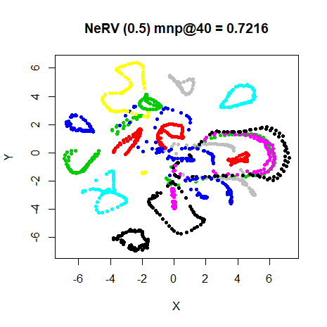

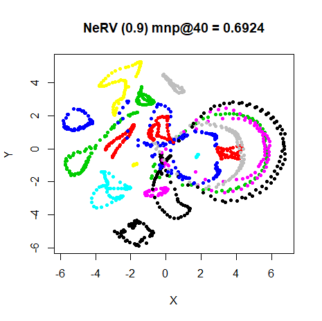

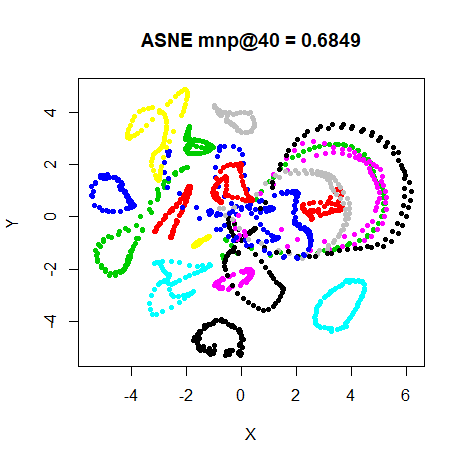

### mnist

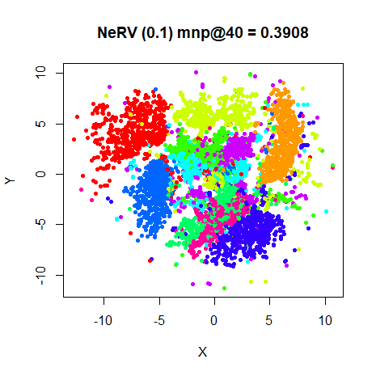

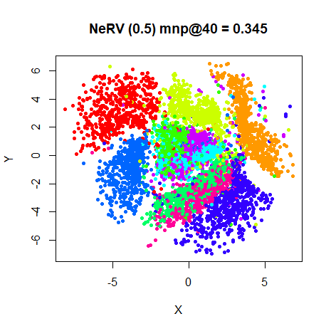

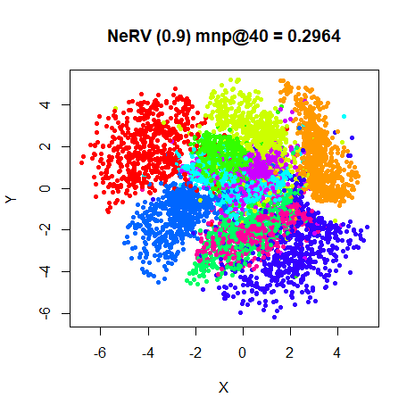

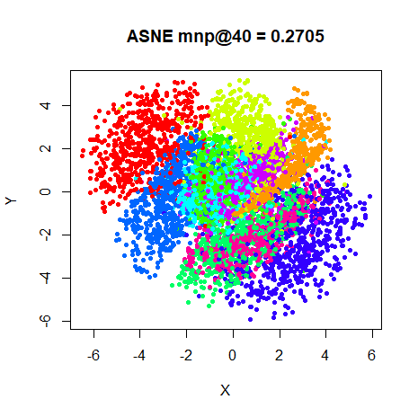

### fashion

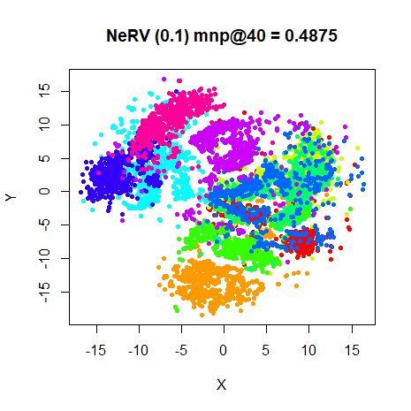

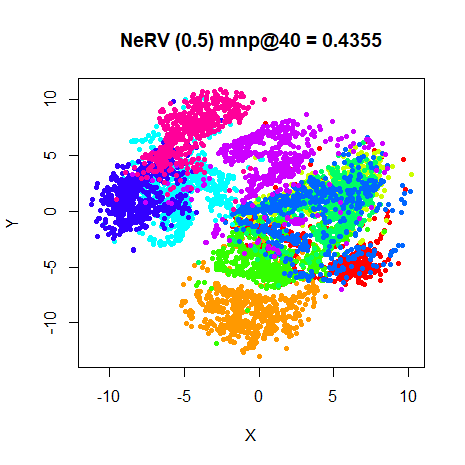

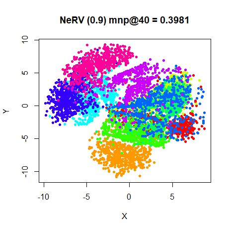

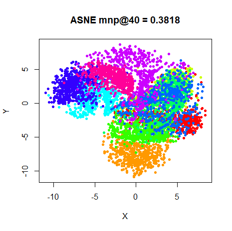

NeRV results with `lambda = 0.9` are very similar to ASNE for the smaller datasets. But there is a mild improvement in separation of clusters for `coil20`, `fashion6k` and `mnist`.